# Week 8_Logistic Regressionl_Loan_Delinquency-Copy1

### Context

DRS bank is facing challenging times. Their NPAs (Non-Performing Assets) has been on a rise recently and a large part of these are due to the loans given to individual customers(borrowers). Chief Risk Officer of the bank decides to put in a scientifically robust framework for approval of loans to individual customers to minimize the risk of loans converting into NPAs and initiates a project for the data science team at the bank. You, as a senior member of the team, are assigned this project.

### Objective

To identify the criteria to approve loans for an individual customer such that the likelihood of the loan delinquency is minimized

## Key questions to be answered

### 1. What are the factors that drive the behavior of loan delinquency?

### 2. How de we predict the likelihood of delinquncy?

### Dataset

- ID: Customer ID
- isDelinquent : indicates whether the customer is delinquent or not (1 => Yes, 0 => No)
- term: Loan term in months
- gender: Gender of the borrower
- age: Age of the borrower
- purpose: Purpose of Loan
- home_ownership: Status of borrower's home
- FICO: FICO (i.e. the bureau score) of the borrower

### Domain Information

- Transactor – A person who pays his due amount balance full and on time.
- Revolver – A person who pays the minimum due amount but keeps revolving his balance and does not pay the full amount.
- Delinquent - Delinquency means that you are behind on payments, a person who fails to pay even the minimum due amount.
- Defaulter – Once you are delinquent for a certain period your lender will declare you to be in the default stage.
- Risk Analytics – A wide domain in the financial and banking industry, basically analyzing the risk of the customer.

### Import the necessary packages

```python
# this will help in making the Python code more structured automatically (good coding practice)
%load_ext nb_black

# Library to suppress warnings or deprecation notes
import warnings

warnings.filterwarnings("ignore")

# Libraries to help with reading and manipulating data

import pandas as pd
import numpy as np

# To perform statistical analysis
import scipy.stats as stats

# Library to split data
from sklearn.model_selection import train_test_split

# libaries to help with data visualization
import matplotlib.pyplot as plt
import seaborn as sns

# Removes the limit for the number of displayed columns
pd.set_option("display.max_columns", None)
# Sets the limit for the number of displayed rows
pd.set_option("display.max_rows", 200)

# To build logistic regression model
from sklearn.linear_model import LogisticRegression

# To get diferent metric scores
from sklearn.metrics import (
    f1_score,
    accuracy_score,
    recall_score,
    precision_score,
    confusion_matrix,
    plot_confusion_matrix,
    roc_auc_score,
    precision_recall_curve,
    roc_curve,
    make_scorer,
)
```

### Read the dataset

```python
data = pd.read_csv("Loan_Delinquent_Dataset.csv")
```

```python
# copying data to another varaible to avoid any changes to original data
loan = data.copy()
```

### View the first and last 5 rows of the dataset.

```python
loan.head()
```

|  | ID | isDelinquent | term | gender | purpose | home_ownership | age | FICO |
| --- | --- | --- | --- | --- | --- | --- | --- | --- |
| 0 | 1 | 1 | 36 months | Female | House | Mortgage | >25 | 300-500 |
| 1 | 2 | 0 | 36 months | Female | House | Rent | 20-25 | >500 |
| 2 | 3 | 1 | 36 months | Female | House | Rent | >25 | 300-500 |
| 3 | 4 | 1 | 36 months | Female | Car | Mortgage | >25 | 300-500 |
| 4 | 5 | 1 | 36 months | Female | House | Rent | >25 | 300-500 |

```python
loan.tail()
```

|  | ID | isDelinquent | term | gender | purpose | home_ownership | age | FICO |
| --- | --- | --- | --- | --- | --- | --- | --- | --- |
| 11543 | 11544 | 0 | 60 months | Male | other | Mortgage | >25 | 300-500 |
| 11544 | 11545 | 1 | 36 months | Male | House | Rent | 20-25 | 300-500 |
| 11545 | 11546 | 0 | 36 months | Female | Personal | Mortgage | 20-25 | >500 |
| 11546 | 11547 | 1 | 36 months | Female | House | Rent | 20-25 | 300-500 |
| 11547 | 11548 | 1 | 36 months | Male | Personal | Mortgage | 20-25 | 300-500 |

### Understand the shape of the dataset.

```python
loan.shape
```

```
(11548, 8)
```

- The dataset has 11548 rows and 8 columns of data

### Check the data types of the columns for the dataset.

```python
loan.info()
```

```
<class 'pandas.core.frame.DataFrame'>
RangeIndex: 11548 entries, 0 to 11547
Data columns (total 8 columns):
 #   Column          Non-Null Count  Dtype
---  ------          --------------  -----
 0   ID              11548 non-null  int64
 1   isDelinquent    11548 non-null  int64
 2   term            11548 non-null  object
 3   gender          11548 non-null  object
 4   purpose         11548 non-null  object
 5   home_ownership  11548 non-null  object
 6   age             11548 non-null  object
 7   FICO            11548 non-null  object
dtypes: int64(2), object(6)
memory usage: 721.9+ KB
```

**Observations -**

- isDelinquent is the dependent variable - type integer.
- All the dependent variables except for ID are object type.

### Summary of the dataset.

```python
loan.describe(include="all")
```

|  | ID | isDelinquent | term | gender | purpose | home_ownership | age | FICO |
| --- | --- | --- | --- | --- | --- | --- | --- | --- |
| count | 11548.000000 | 11548.000000 | 11548 | 11548 | 11548 | 11548 | 11548 | 11548 |
| unique | NaN | NaN | 2 | 2 | 7 | 3 | 2 | 2 |
| top | NaN | NaN | 36 months | Male | House | Mortgage | 20-25 | 300-500 |
| freq | NaN | NaN | 10589 | 6555 | 6892 | 5461 | 5888 | 6370 |
| mean | 5774.500000 | 0.668601 | NaN | NaN | NaN | NaN | NaN | NaN |
| std | 3333.764789 | 0.470737 | NaN | NaN | NaN | NaN | NaN | NaN |
| min | 1.000000 | 0.000000 | NaN | NaN | NaN | NaN | NaN | NaN |
| 25% | 2887.750000 | 0.000000 | NaN | NaN | NaN | NaN | NaN | NaN |
| 50% | 5774.500000 | 1.000000 | NaN | NaN | NaN | NaN | NaN | NaN |
| 75% | 8661.250000 | 1.000000 | NaN | NaN | NaN | NaN | NaN | NaN |
| max | 11548.000000 | 1.000000 | NaN | NaN | NaN | NaN | NaN | NaN |

**Observations-**

- Most of the loans are for a 36-month term loan.
- More males have applied for loans than females.
- Most loan applications are for house loans.
- Most customers have either mortgaged their houses.
- Mostly customers in the age group 20-25 have applied for a loan.
- Most customers have a FICO score between 300 and 500.

```python
loan.isDelinquent.value_counts()
```

```
1    7721
0    3827
Name: isDelinquent, dtype: int64
```

```python
# checking for unique values in ID column
loan["ID"].nunique()
```

```
11548
```

- Since all the values in ID column are unique we can drop it

```python
loan.drop(["ID"], axis=1, inplace=True)
```

### Check for missing values

```python
loan.isnull().sum()
```

```
isDelinquent      0
term              0
gender            0
purpose           0
home_ownership    0
age               0
FICO              0
dtype: int64
```

- There are no missing vaues in out dataset

### Univariate analysis

```python
# function to create labeled barplots


def labeled_barplot(data, feature, perc=False, n=None):
    """
    Barplot with percentage at the top

    data: dataframe
    feature: dataframe column
    perc: whether to display percentages instead of count (default is False)
    n: displays the top n category levels (default is None, i.e., display all levels)
    """

    total = len(data[feature])  # length of the column
    count = data[feature].nunique()
    if n is None:
        plt.figure(figsize=(count + 2, 6))
    else:
        plt.figure(figsize=(n + 2, 6))

    plt.xticks(rotation=90, fontsize=15)
    ax = sns.countplot(
        data=data,
        x=feature,
        palette="Paired",
        order=data[feature].value_counts().index[:n].sort_values(),
    )

    for p in ax.patches:
        if perc == True:
            label = "{:.1f}%".format(
                100 * p.get_height() / total
            )  # percentage of each class of the category
        else:
            label = p.get_height()  # count of each level of the category

        x = p.get_x() + p.get_width() / 2  # width of the plot
        y = p.get_height()  # height of the plot

        ax.annotate(
            label,
            (x, y),
            ha="center",
            va="center",
            size=12,
            xytext=(0, 5),
            textcoords="offset points",
        )  # annotate the percentage

    plt.show()  # show the plot
```

## Observations on isDelinquent

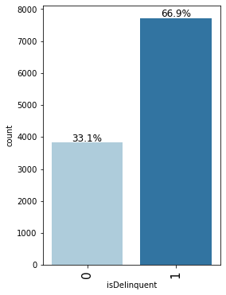

```python
labeled_barplot(loan, "isDelinquent", perc=True)
```

- 66.9% of the customers are delinquent

## Observations on term

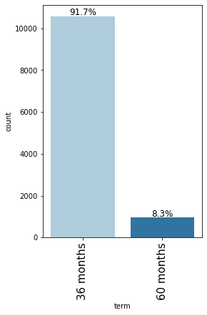

```python
labeled_barplot(loan, "term", perc=True)
```

- 91.7% of the loans are for a 36 month term.

## Observations on gender

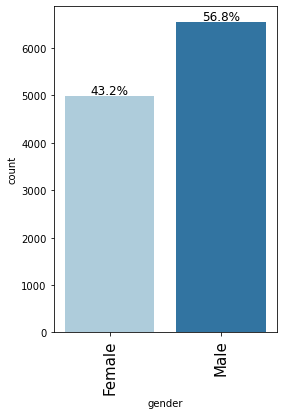

```python
labeled_barplot(loan, "gender", perc=True)
```

- There are more male applicants (56.8%) than female applicants (43.2%)

## Observations on purpose

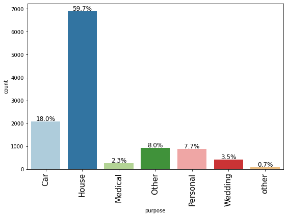

```python
labeled_barplot(loan, "purpose", perc=True)
```

- Most loan applications are for house loans (59.7%) followed by car loans (18%)
- There are 2 levels named 'other' and 'Other' under the purpose variable. Since we do not have any other information about these, we can merge these levels.

## Observations on home_ownership

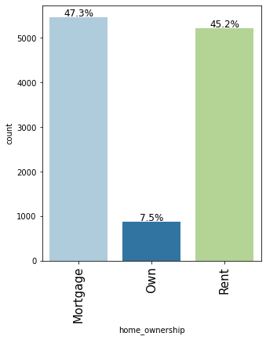

```python
labeled_barplot(loan, "home_ownership", perc=True)
```

- Very few applicants <10% own their house, Most customers have either mortgaged their houses or live on rent.

## Observations on age

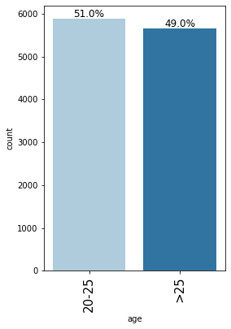

```python
labeled_barplot(loan, "age", perc=True)
```

- Almost an equal percentage of people aged 20-25 and >25 have applied for the loan.

## Observations on FICO

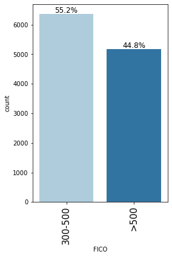

```python
labeled_barplot(loan, "FICO", perc=True)
```

- Most customers have a FICO score between 300 and 500 (55.2%) followed by a score of greater than 500 (44.8%)

## Data Cleaning

```python
loan["purpose"].unique()
```

```
array(['House', 'Car', 'Other', 'Personal', 'Wedding', 'Medical', 'other'],
      dtype=object)
```

### We can merge the purpose - 'other' and 'Other' together

```python
loan["purpose"].replace("other", "Other", inplace=True)
```

```python
loan["purpose"].unique()
```

```
array(['House', 'Car', 'Other', 'Personal', 'Wedding', 'Medical'],
      dtype=object)
```

## Bivariate Analysis

```python
# function to plot stacked bar chart


def stacked_barplot(data, predictor, target):
    """
    Print the category counts and plot a stacked bar chart

    data: dataframe
    predictor: independent variable
    target: target variable
    """
    count = data[predictor].nunique()
    sorter = data[target].value_counts().index[-1]
    tab1 = pd.crosstab(data[predictor], data[target], margins=True).sort_values(
        by=sorter, ascending=False
    )
    print(tab1)
    print("-" * 120)
    tab = pd.crosstab(data[predictor], data[target], normalize="index").sort_values(
        by=sorter, ascending=False
    )
    tab.plot(kind="bar", stacked=True, figsize=(count + 5, 6))
    plt.legend(
        loc="lower left",
        frameon=False,
    )
    plt.legend(loc="upper left", bbox_to_anchor=(1, 1))
    plt.show()
```

```
isDelinquent     0     1    All
term
All           3827  7721  11548
36 months     3168  7421  10589
60 months      659   300    959
------------------------------------------------------------------------------------------------------------------------
```

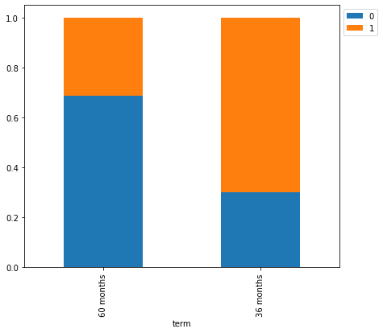

```python
stacked_barplot(loan, "term", "isDelinquent")
```

- Most loan delinquent customers have taken loan for 36 months.

```
isDelinquent     0     1    All
gender
All           3827  7721  11548
Male          1977  4578   6555
Female        1850  3143   4993
------------------------------------------------------------------------------------------------------------------------
```

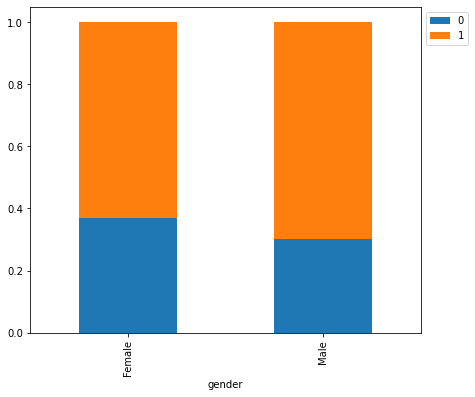

```python
stacked_barplot(loan, "gender", "isDelinquent")
```

#### Males seem to be slightly more delinquent than females

```
isDelinquent     0     1    All
purpose
All           3827  7721  11548
House         2272  4620   6892
Car            678  1402   2080
Other          357   653   1010
Personal       274   618    892
Wedding        139   269    408
Medical        107   159    266
------------------------------------------------------------------------------------------------------------------------
```

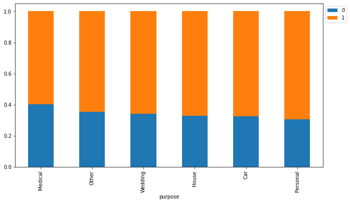

```python
stacked_barplot(loan, "purpose", "isDelinquent")
```

#### The delinquency ratio is more for customers who took loan for personal purposes

```
isDelinquent       0     1    All
home_ownership
All             3827  7721  11548
Mortgage        1831  3630   5461
Rent            1737  3479   5216
Own              259   612    871
------------------------------------------------------------------------------------------------------------------------
```

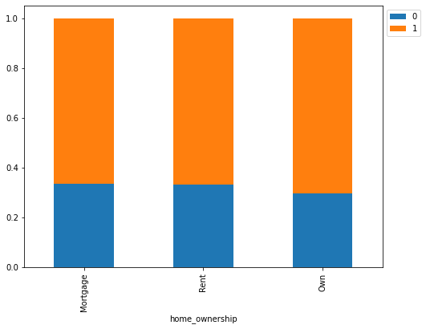

```python
stacked_barplot(loan, "home_ownership", "isDelinquent")
```

```
isDelinquent     0     1    All
age
All           3827  7721  11548
>25           1969  3691   5660
20-25         1858  4030   5888
------------------------------------------------------------------------------------------------------------------------
```

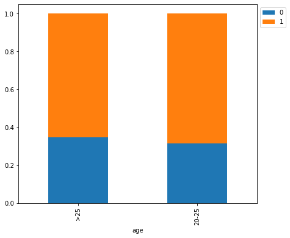

```python
stacked_barplot(loan, "age", "isDelinquent")
```

```
isDelinquent     0     1    All
FICO
All           3827  7721  11548
>500          2886  2292   5178
300-500        941  5429   6370
------------------------------------------------------------------------------------------------------------------------
```

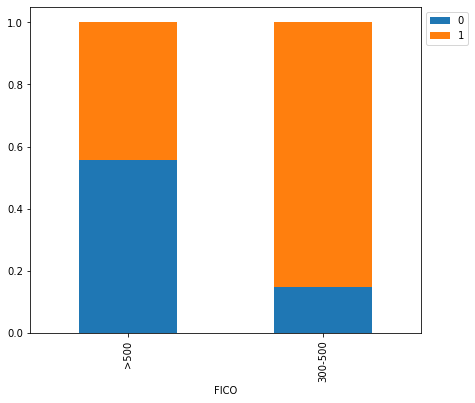

```python
stacked_barplot(loan, "FICO", "isDelinquent")
```

#### If FICO score is >500 the chances of delinquency decrease quite a lot compared to when FICO score is between 300-500.

### Key Observations -

- FICO score and term of loan application appear to be very strong indicators of delinquency.
- Other factors appear to be not very good indicators of delinquency. (We can use chi-square tests to determine statistical significance in the association between two categorical variables).

### We observed that a high FICO score means that the chances of delinquency are lower, let us see if any of the other variables indicate a higher FICO score.

```
FICO            300-500  >500    All
home_ownership
All                6370  5178  11548
Mortgage           2857  2604   5461
Rent               3033  2183   5216
Own                 480   391    871
------------------------------------------------------------------------------------------------------------------------
```

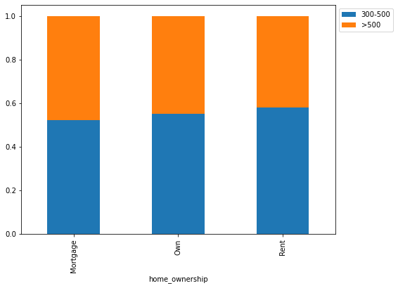

```python
stacked_barplot(loan, "home_ownership", "FICO")
```

```
FICO   300-500  >500    All
age
All       6370  5178  11548
>25       2443  3217   5660
20-25     3927  1961   5888
------------------------------------------------------------------------------------------------------------------------
```

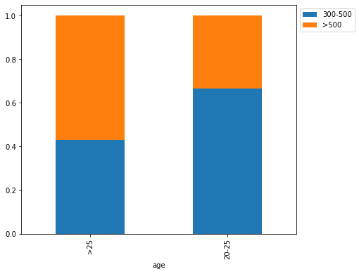

```python
stacked_barplot(loan, "age", "FICO")
```

#### More customers > 25 years of age have FICO scores> 500, compared to younger customers

```
FICO    300-500  >500    All
gender
All        6370  5178  11548
Male       3705  2850   6555
Female     2665  2328   4993
------------------------------------------------------------------------------------------------------------------------
```

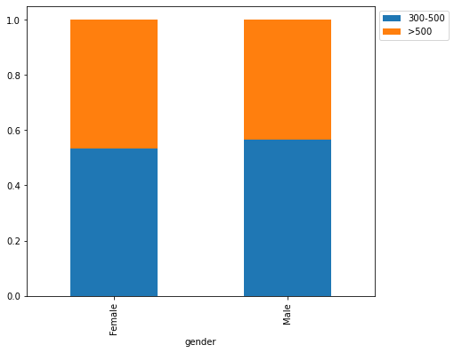

```python
stacked_barplot(loan, "gender", "FICO")
```

## Key Observations

1. Home ownership and gender seem to have a slight impact on the FICO scores.
2. Age seems to have a much bigger impact on FICO scores.

### Let us check which of these differences are statistically significant.

The Chi-Square test is a statistical method to determine if two categorical variables have a significant correlation between them.

**Null Hypothesis -** There is no association between the two variables.  
**Alternate Hypothesis -** There is an association between two variables.

```python
crosstab = pd.crosstab(
    loan["FICO"], loan["home_ownership"]
)  # Contingency table of FICO and home_ownership attributes

Ho = "Home Ownership has no effect on FICO score"  # Stating the Null Hypothesis
Ha = "HOme ownerhsip has an effect on FICO score"  # Stating the Alternate Hypothesis

chi, p_value, dof, expected = stats.chi2_contingency(crosstab)

if p_value < 0.05:  # Setting our significance level at 5%
    print(f"{Ha} as the p_value ({p_value.round(3)}) < 0.05")
else:
    print(f"{Ho} as the p_value ({p_value.round(3)}) > 0.05")
```

```
HOme ownerhsip has an effect on FICO score as the p_value (0.0) < 0.05
```

```python
crosstab = pd.crosstab(
    loan["FICO"], loan["gender"]
)  # Contingency table of FICO and gender attributes

Ho = "Gender has no effect on FICO score"  # Stating the Null Hypothesis
Ha = "Gender has an efect on FICO score"  # Stating the Alternate Hypothesis

chi, p_value, dof, expected = stats.chi2_contingency(crosstab)

if p_value < 0.05:  # Setting our significance level at 5%
    print(f"{Ha} as the p_value ({p_value.round(3)}) < 0.05")
else:
    print(f"{Ho} as the p_value ({p_value.round(3)}) > 0.05")
```

```
Gender has an efect on FICO score as the p_value (0.001) < 0.05
```

```python
crosstab = pd.crosstab(
    loan["FICO"], loan["age"]
)  # Contingency table of FICO and age attributes

Ho = "Age has no effect on FICO score"  # Stating the Null Hypothesis
Ha = "Age has an effect on FICO score"  # Stating the Alternate Hypothesis

chi, p_value, dof, expected = stats.chi2_contingency(crosstab)

if p_value < 0.05:  # Setting our significance level at 5%
    print(f"{Ha} as the p_value ({p_value.round(3)}) < 0.05")
else:
    print(f"{Ho} as the p_value ({p_value.round(3)}) > 0.05")
```

```
Age has an effect on FICO score as the p_value (0.0) < 0.05
```

## Key Observations-

- P-value for all tests < 0.01. Hence, all the differences that we see in the 3 plots are statistically significant.
- There is a correlation between FICO Score and house_ownership. People who have mortgaged their houses have higher FICO scores than people who own the house.
- There is a correlation between FICO Score and gender. More females have >500 FICO scores as compared to Males.
- There is a correlation between FICO Score and age. People >25 years of age have higher FICO scores as compared to people of age 20-25.

## Model Building - Approach

1. Data preparation
2. Partition the data into train and test set.
3. Built a Logistic Regression model on the train data.
4. Evaluate the performance and "tune" the model to get the best performanceon the chosen metric

## Using Statsmodels library

```python
# Importing library
import statsmodels.api as sm
from statsmodels.tools.tools import add_constant
```

## Separate data into target and prediction variables and Split Data

```python
X = loan.drop(["isDelinquent"], axis=1)
Y = loan["isDelinquent"]

X = pd.get_dummies(X, drop_first=True)

# adding constant
X = sm.add_constant(X)

# Splitting data in train and test sets
X_train, X_test, y_train, y_test = train_test_split(
    X, Y, test_size=0.30, random_state=1
)
```

## Build Classification Model

### First, let's create functions to calculate different metrics and confusion matrix so that we don't have to use the same code repeatedly for each model.

```python
# defining a function to compute different metrics to check performance of a classification model built using statsmodels
def model_performance_classification(model, predictors, target, threshold=0.5):
    """
    Function to compute different metrics to check classification model performance

    model: classifier
    predictors: independent variables
    target: dependent variable
    threshold: threshold for classifying the observation as class 1
    """

    # checking which probabilities are greater than threshold
    pred_temp = model.predict(predictors) > threshold
    # rounding off the above values to get classes
    pred = np.round(pred_temp)

    acc = accuracy_score(target, pred)  # to compute Accuracy
    recall = recall_score(target, pred)  # to compute Recall
    precision = precision_score(target, pred)  # to compute Precision
    f1 = f1_score(target, pred)  # to compute F1-score

    # creating a dataframe of metrics
    df_perf = pd.DataFrame(
        {
            "Accuracy": acc,
            "Recall": recall,
            "Precision": precision,
            "F1": f1,
        },
        index=[0],
    )

    return df_perf
```

## Build Logistic Regression Model

```python
# fitting logistic regression model
logit = sm.Logit(y_train, X_train.astype(float))
lg = logit.fit(disp=False)

print(lg.summary())
```

```
                           Logit Regression Results
==============================================================================
Dep. Variable:           isDelinquent   No. Observations:                 8083
Model:                          Logit   Df Residuals:                     8071
Method:                           MLE   Df Model:                           11
Date:                Thu, 28 Oct 2021   Pseudo R-squ.:                  0.2051
Time:                        11:21:24   Log-Likelihood:                -4056.5
converged:                       True   LL-Null:                       -5102.8
Covariance Type:            nonrobust   LLR p-value:                     0.000
=======================================================================================
                          coef    std err          z      P>|z|      [0.025      0.975]
---------------------------------------------------------------------------------------
const                   1.0712      0.091     11.787      0.000       0.893       1.249
term_60 months         -2.0559      0.112    -18.401      0.000      -2.275      -1.837
gender_Male             0.8024      0.060     13.479      0.000       0.686       0.919
purpose_House           0.1287      0.074      1.745      0.081      -0.016       0.273
purpose_Medical         0.2350      0.199      1.180      0.238      -0.155       0.625
purpose_Other           0.1495      0.113      1.321      0.186      -0.072       0.371
purpose_Personal        0.2902      0.122      2.370      0.018       0.050       0.530
purpose_Wedding         0.0890      0.157      0.567      0.570      -0.218       0.396
home_ownership_Own      0.2713      0.112      2.420      0.016       0.052       0.491
home_ownership_Rent    -0.0837      0.059     -1.431      0.152      -0.198       0.031
age_>25                 0.7329      0.060     12.228      0.000       0.615       0.850
FICO_>500              -2.1169      0.058    -36.370      0.000      -2.231      -2.003
=======================================================================================
```

## We can interpret the effect of predictor variables having p-value <.05

#### We can interpret the sign of coefficients that have a p-vlaue <.05.

1. For example, we can say that if the loan term is 60 monts (vs 36 months) the chance of delinquency are less.
2. Similarly, having a FICO score >500 decresese the chances of delinquency

## We can have more exact interpretation by converting the coefficients to odds.

1Converting coefficients to odds The coefficients of the logistic regression model are in terms of log(odd), to find the odds we have to take the exponential of the coefficients. Therefore, odds = exp(b) The percentage change in odds is given as odds = (exp(b) - 1) * 100

### However, this would be useful if the predictor variables are continuous. In that case we can calculate how much the odds of delinquency increase with one unit increase in the continous variable. But, our focus here is more on PREDICTION rather than on understanding the detatils of the impact by various variables

## Business Insights from EDA and statistical tests

- FICO, term and gender are the more important variables in determining if a borrower will get into a delinquent stage
- No borrower should be given a loan if they are applying for a 36 month term loan and have a FICO score in the range 300-500.
- Female borrowers with a FICO score greater than 500 should be our target customers (least cahnce of delinquency).
- Criteria to approve loan according to the model should depend on three main factors - FICO score, duration of loan and gender that is - If the FICO score is less than 500 and the duration of loan is less than 60 months then the customer may not be able to repay the loans. If the customer has greater than 500 FICO score and is a female higher chances that they will repay the loans.

#### Checking model performance on training set

```python
print("Training performance:")
model_performance_classification(lg, X_train, y_train)
```

```
Training performance:
```

|  | Accuracy | Recall | Precision | F1 |
| --- | --- | --- | --- | --- |
| 0 | 0.79859 | 0.877019 | 0.832985 | 0.854435 |

## Making a Confusion Matrix

### We define a function that will generate a Confusion Matrix with all details

```python
# defining a function to plot the confusion_matrix of a classification model


def confusion_matrix_statsmodels(model, predictors, target, threshold=0.5):
    """
    To plot the confusion_matrix with percentages

    model: classifier
    predictors: independent variables
    target: dependent variable
    threshold: threshold for classifying the observation as class 1
    """
    y_pred = model.predict(predictors) > threshold
    cm = confusion_matrix(target, y_pred)
    group_names = ["True Neg", "False Pos", "False Neg", "True Pos"]
    group_counts = ["{0:0.0f}".format(value) for value in cm.flatten()]
    group_percentages = ["{0:.2%}".format(value) for value in cm.flatten() / np.sum(cm)]
    labels = [
        f"{v1}\n{v2}\n{v3}"
        for v1, v2, v3 in zip(group_names, group_counts, group_percentages)
    ]
    labels = np.asarray(labels).reshape(2, 2)
    sns.heatmap(cm, annot=labels, fmt="", cmap="Blues")
```

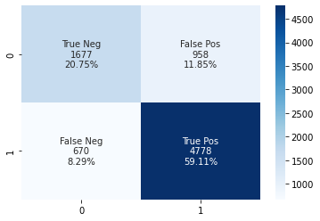

```python
confusion_matrix_statsmodels(lg, X_train, y_train, threshold=0.5)
```

#### Checking model performance on test set

```python
print("Test performance:")
model_performance_classification(lg, X_test, y_test)
```

```
Test performance:
```

|  | Accuracy | Recall | Precision | F1 |
| --- | --- | --- | --- | --- |
| 0 | 0.786436 | 0.863176 | 0.820577 | 0.841338 |

### The various performance metrics on train and test data are similar. This indicates that the model is not overfitting. Further, the metrics have high values, indicating the the model is not underfitting either. In short, the model is giving good and generalized results.

### 1. The model is able to correctly flag 86 % (recall) of likely delinquents

### 2. The model's prediction of default is correct 82% of the time

### 3. The model is fairly balanced, with a f1 score of 0.84

### Model evaluation criterion

### Model can make wrong predictions as:

1. Predicting a customer will not be behind on payments (Non-Delinquent) but in reality the customer would be behind on payments (FN).
2. Predicting a customer will be behind on payments (Delinquent) but in reality the customer would not be behind on payments (Non-Delinquent) (FP).

### Which case is more important?

- If the model predicts a non-delinquent customer as a delinquent customer (FP), bank would lose an opportunity of providing loan to a potential customer. If we consider this important, we would prefer number FP to be low
- Or, if the model predicts a delinquent customer as non-delinquent (FN), the bank would suffer financial loss. Suppose we consider this more important, then we would want FN to be low

### How to reduce this loss i.e need to reduce False Negatives?

- Remember, Recall = (TP)/(TP+FN)
- Therefore in this scenario,`recall` should be maximized: the greater the recall smaller the false negatives.

## Let's see how we can improve the model to maximize Recall

### Since Logistic Regression generates probability of each event and classifies each event as "0" or "1" based on the threshold (default = 0.5), we can adjust the performance of the model by changing the threshold value

## If we increase the thrshold, say to 0.8, the model will predict the class of interest (1) only if the probability of default is >0.8. This means that its predictions of default will be more accurate (Precision will be more). However, a decrease in FP will also reduce TP, whereby model will miss many cases that should have been flagged as delinquent

## On the other hand, if we decrease the threshold, say to 0.3, The model will catch more delinquent cases (Recall will be more) but will also have more mishits (larger FP)

## We could also aim to find the "sweet spot", i.e. the threshold value that maximizes Recall without sacrificing on other important metrics

## Model evaluation using ROC-AUC; How skilled the model is?

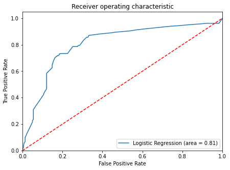

```python
logit_roc_auc_train = roc_auc_score(y_train, lg.predict(X_train))
fpr, tpr, thresholds = roc_curve(y_train, lg.predict(X_train))
plt.figure(figsize=(7, 5))
plt.plot(fpr, tpr, label="Logistic Regression (area = %0.2f)" % logit_roc_auc_train)
plt.plot([0, 1], [0, 1], "r--")
plt.xlim([0.0, 1.0])
plt.ylim([0.0, 1.05])
plt.xlabel("False Positive Rate")
plt.ylabel("True Positive Rate")
plt.title("Receiver operating characteristic")
plt.legend(loc="lower right")
plt.show()
```

### The model is definitely better than an "unskilled model" represented by the red line. The area under the curve is a mesure of the "skill" of the model.

## Using Precision-Recall curve to find a good threshold

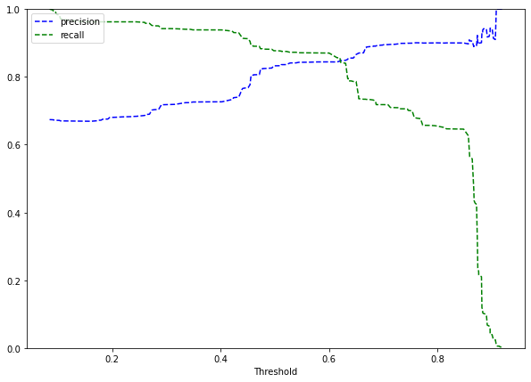

```python
y_scores = lg.predict(X_train)
prec, rec, tre = precision_recall_curve(
    y_train,
    y_scores,
)


def plot_prec_recall_vs_tresh(precisions, recalls, thresholds):
    plt.plot(thresholds, precisions[:-1], "b--", label="precision")
    plt.plot(thresholds, recalls[:-1], "g--", label="recall")
    plt.xlabel("Threshold")
    plt.legend(loc="upper left")
    plt.ylim([0, 1])


plt.figure(figsize=(10, 7))
plot_prec_recall_vs_tresh(prec, rec, tre)
plt.show()
```

### It appears that Precision and recall may be balanced at a thrshold around 0.62

```python
print("Training performance:")
model_performance_classification(lg, X_train, y_train, threshold=0.62)
```

```
Training performance:
```

|  | Accuracy | Recall | Precision | F1 |
| --- | --- | --- | --- | --- |
| 0 | 0.798961 | 0.856645 | 0.846852 | 0.85172 |

## If we want high Recall, we can adjust the threshold lower

```python
log_reg_model_train_perf_threshold_curve = model_performance_classification(
    lg, X_train, y_train, threshold=0.3
)
print("Training performance:")
log_reg_model_train_perf_threshold_curve
```

```
Training performance:
```

|  | Accuracy | Recall | Precision | F1 |
| --- | --- | --- | --- | --- |
| 0 | 0.711988 | 0.942548 | 0.718182 | 0.815209 |

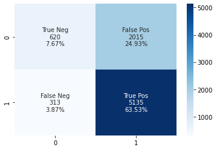

```python
confusion_matrix_statsmodels(lg, X_train, y_train, threshold=0.3)
```

```python
log_reg_model_test_perf_threshold_curve = model_performance_classification(
    lg, X_test, y_test, threshold=0.3
)
print("test performance:")
log_reg_model_test_perf_threshold_curve
```

```
test performance:
```

|  | Accuracy | Recall | Precision | F1 |
| --- | --- | --- | --- | --- |
| 0 | 0.700144 | 0.930488 | 0.705941 | 0.802809 |

## The model with threshold = 0.3 is not overfitting and has high recall. The model will be able to flag 93% of likely delinquents. We may choose this as the final model to predict delinquency and decide loan approvals